# NMDS Analysis

SKammlade

January 4, 2017

#### About the analyses

NMDS coordinates were found using the *metaMDS()* function from the *vegan* package.

```r
library(vegan)
metaMDS(comm = data,
        distance = "bray",
        k = 2,
        trymax = 20,
        stratmax = 0.9999999999)
```

**Stressplots** (or Shepard diagrams) are used to visualize the fit of the ordination.

```r
library(vegan)
stressplot(data)
```

Using [*stressplot()*](http://cc.oulu.fi/~jarioksa/opetus/metodi/vegantutor.pdf) from R package *vegan*.

```r
library(goeveg)
dimcheckMDS(data,
            distance = "bray",
            k = 8,
            trymax = 20,
            autotransform = TRUE)
```

Using [*dimcheckMDS()*](https://cran.r-project.org/web/packages/goeveg/goeveg.pdf) from R package *goeveg*.

Below you will find diagnostic tests of the analysis for each Measurement.

#### Calories

#### – NMDS results

No convergent solutions found for decades data or 3yrs when k=2 (2 dimentions).

#### – Stress Value Tests

Stress Value Tests indicate ordination should be done over 3 dimensions.

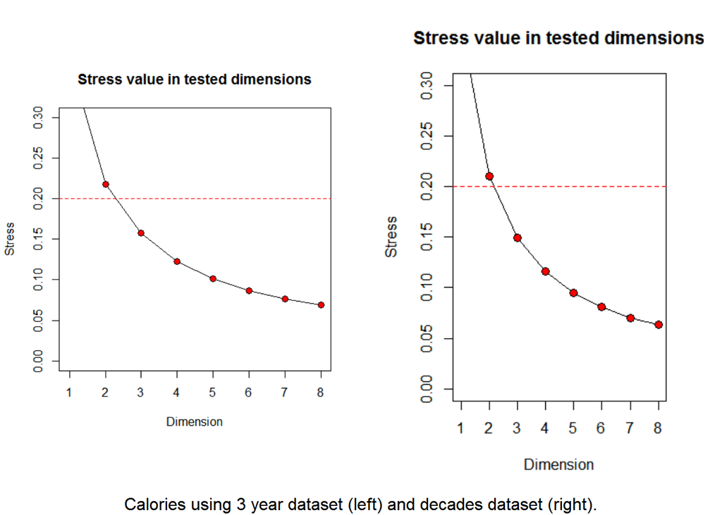

#### – Stressplots

Stressplots performed over 2 dimensions

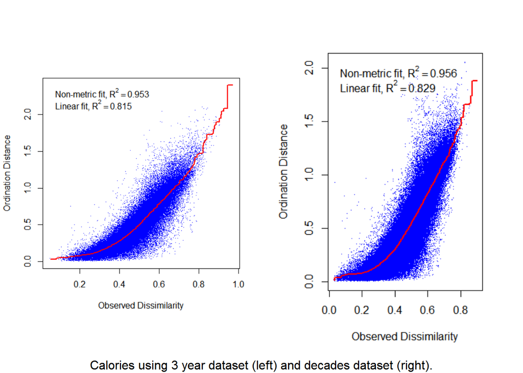

As a comparison, here is a stressplot from using data from all years which we abandoned back in November.

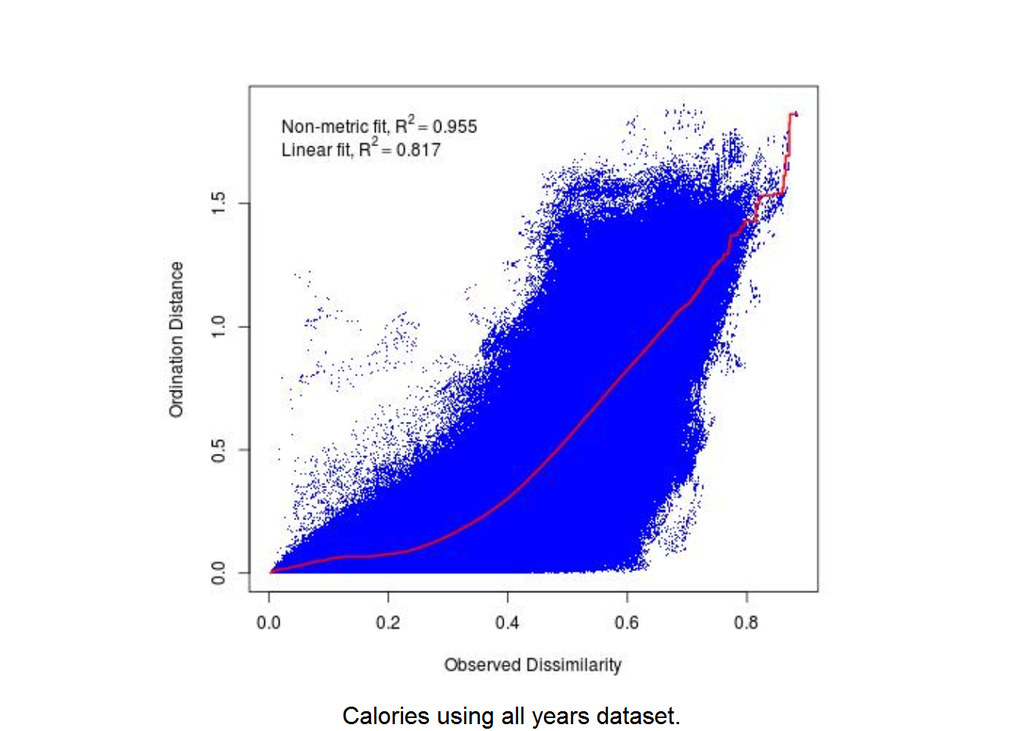

Here’s what the stressplots look like done over 3 dimensions as recommended by the stress value test.

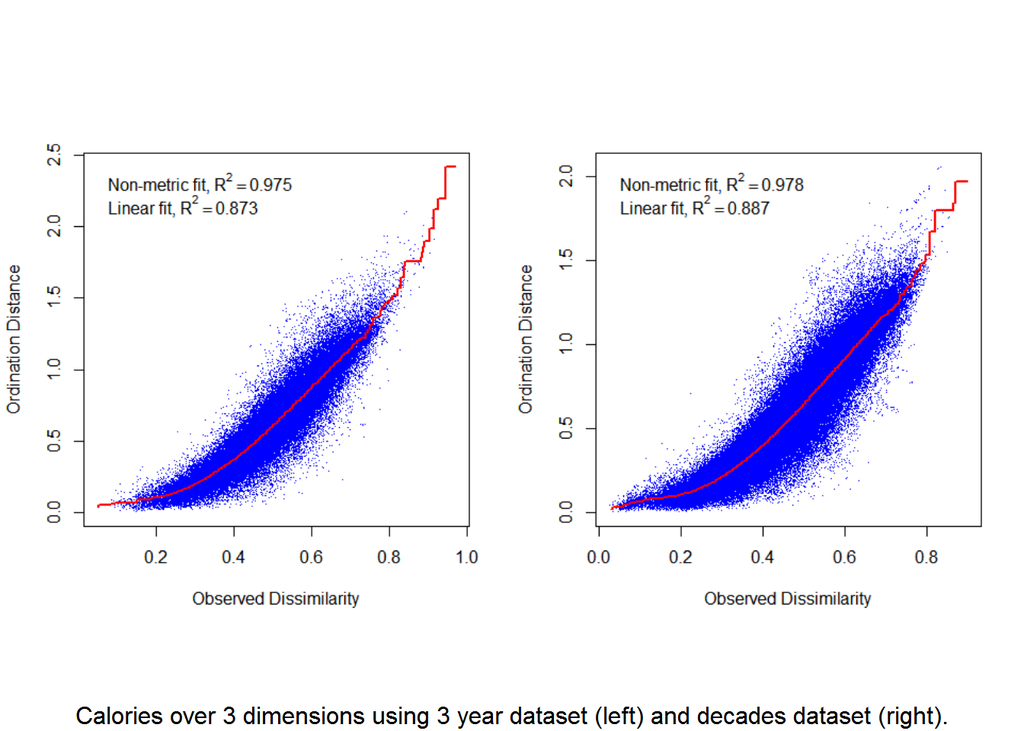

#### Fat

#### – NMDS results

No convergent solutions found for decades data or 3yrs.

#### – Stress Value Tests

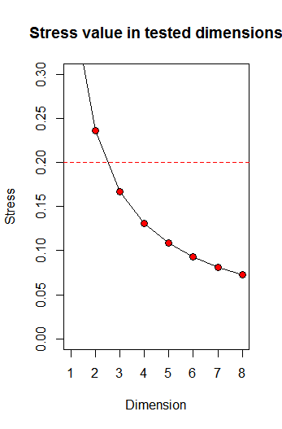

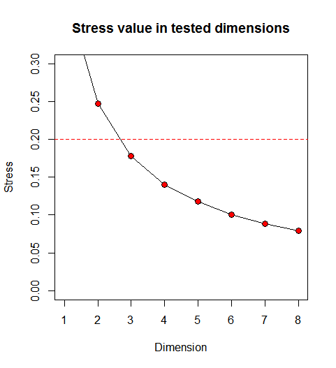

###### Fat by decade (left), three years as in manuscript (right).

#### – Stressplots

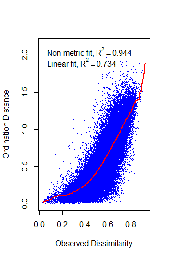

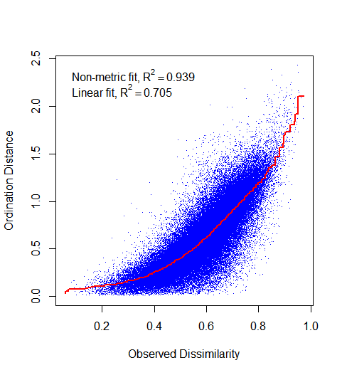

###### Fat by decade (left), three years as in manuscript (right).

#### Protein

#### – NMDS results

No convergent solutions found for decades data or 3yrs.

#### – Stress Value Tests

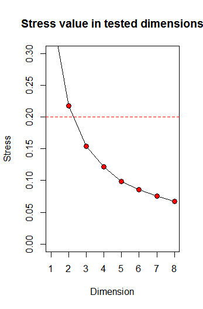

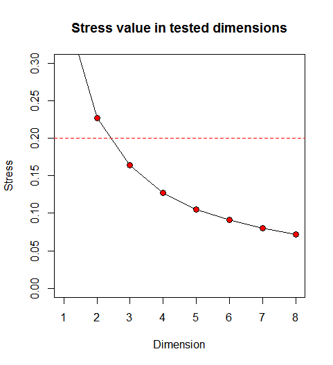

###### Protein by decade (left), three years as in manuscript (right).

#### – Stressplots

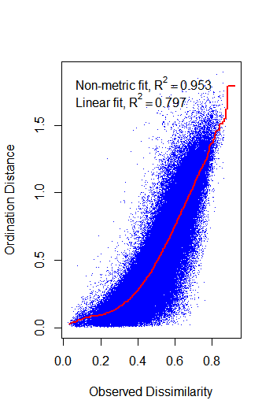

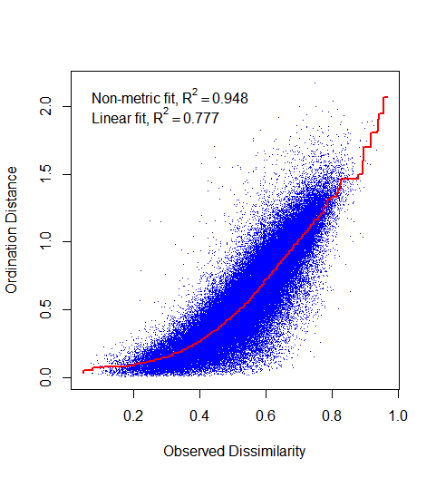

###### Protein by decade (left), three years as in manuscript (right).

#### FoodWeight

#### – NMDS results

No convergent solutions found for decades data or 3yrs.

#### – Stress Value Tests

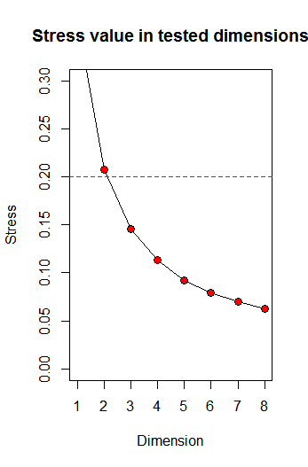

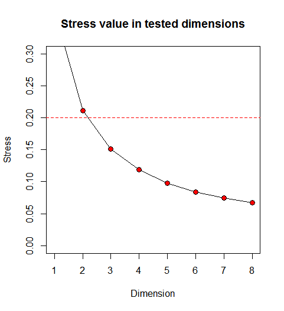

###### FoodWeight by decade (left), three years as in manuscript (right).

#### – Stressplots

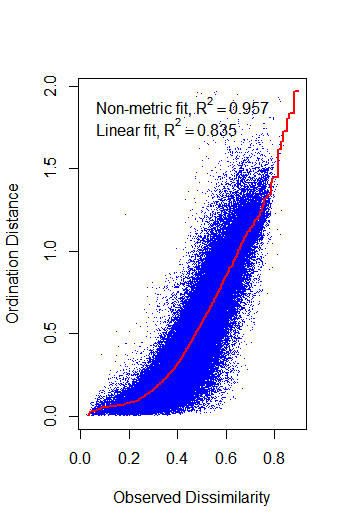

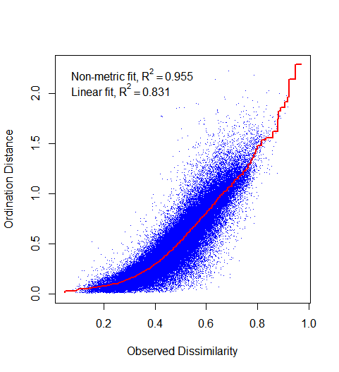

###### FoodWeight by decade (left), three years as in manuscript (right).

#### Scaling in 2 and 3 dimensions

Stress plots suggest convergence will be met when running on 3 dimensions. I ran metaMDS() on 2 and 3 dimensions and plotted them using both coordinates for the results on 2 dimensions, and the firt two dimensions for 3 dimensions.

```r
# 2 dimensions
MDSCalories<-metaMDS(dataNMDSDecadesCropsCalories,
                        distance="bray",
                        k=2,
                        trymax = 20,
                        stratmax=0.9999999999 )

# 3 dimensions
MDSCalories3Dim<-metaMDS(dataNMDSDecadesCropsCalories,
                       distance="bray",
                       k=3,
                       trymax = 20,
                       stratmax=0.9999999999 )
```

#### – Calories Plots

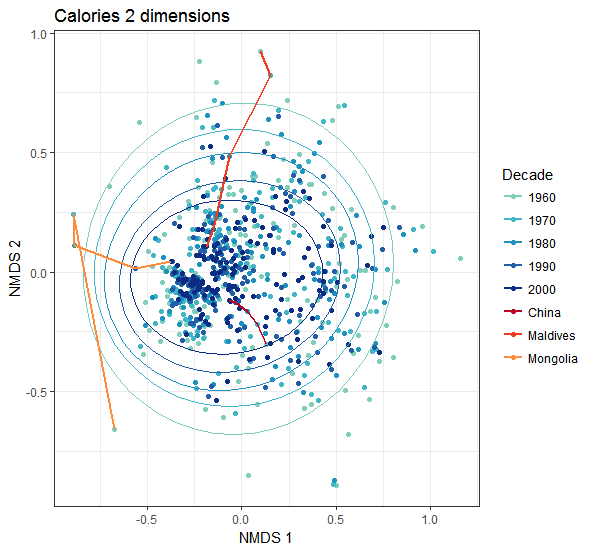

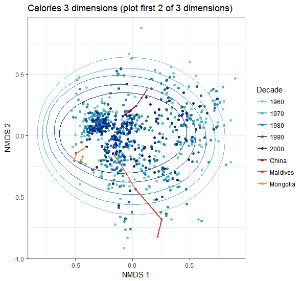

#### – Fat Plots

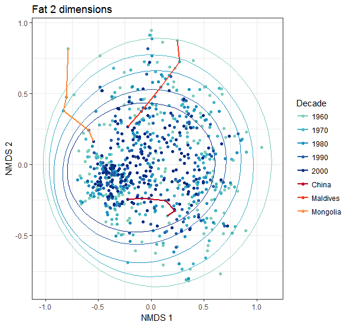

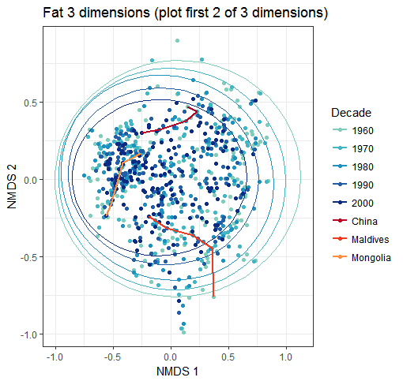

#### – Protein Plots

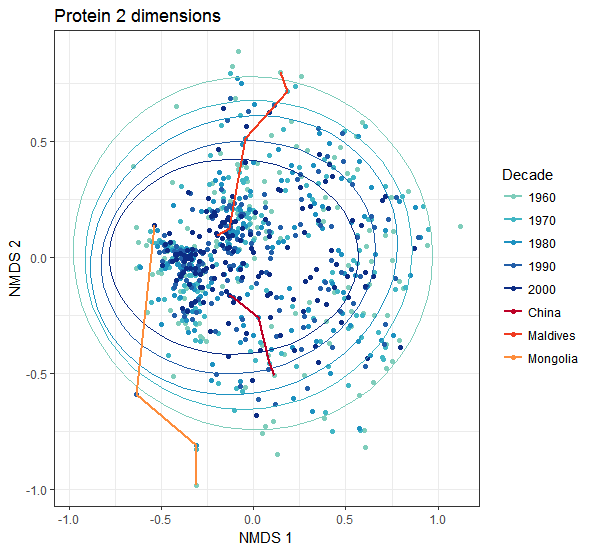

[figure not shown]

#### – FoodWeight Plots

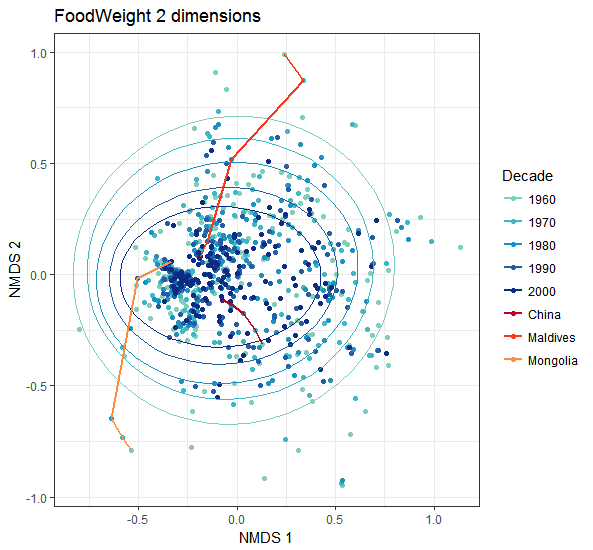

[figure not shown]